# Collect USGS stream observations to evaluate streamflow simulation

Aubrey Dugger, James McCreight, Alyssa Hendricks

2017-05-01

# Background

USGS streamflow observations are a primary source of hydrologic information and often used for validation and calibration of hydrlogic models. Recently, web services have been developed at [*NWIS*](http://waterdata.usgs.gov/nwis) and the [*dataRetrieval*](http://cran.r-project.org/web/packages/dataRetrieval/index.html) R package has emerged to make it easy to get USGS data into R.

This vignette demonstates some rwrfhydro tools to collect, store, and mainipulate USGS within a local database. This data is then used to evaluate model performance in estimating streamflow with and without overland, subsurface, and groundwater routing active. WRF-Hydro was run predict streamflow for Fourmile Creek at the Orodell USGS gage for the 2013 snowmelt period. NoahMP was used as the LSM and a 3-year spinup period was completed prior to the part of the simulation in the test case directory.

The fundamental layout of the local database is simply a directory containing:

- Metadata data base (metaDB): Organized hierarchically by HUC8 -> product id -> siteInfo, variableInfo, statisticInfo where the last three are information fields returned by dataRetrieval::readNWISuv. The information in this file is simply the aggregation of the metadata from all the data files also contained in the same directory.
- Individual data files collected by HUC8: These contain both the meta data for the HUC8 (aggregated in the metadata DB) and all the previously retrieved data for the HUC8.

Generally, there are two basic kinds of functions: “Get” and “Query”. Get functions use dataRetrieval functions to actually go out to NWIS and “get” data and metadata. Query functions query the local database. There are exceptions to this.

# Setup

Load the rwrfhydro package.

```r
library("rwrfhydro")
```

Create a directory and path to where you want your database to be built:

```r
dbPath <- '~/wrfHydroTestCases/usgsDb/'
```

# Discover gage locations, get data, and save to local database.

Perhaps you know the lat/lon of a gage (e.g. from frxst_pts_out.txt) and you need the HUC8. The `within` argument is taken to be in decimal degrees.

```r
stnDf <- FindUsgsStns(stnLon=254.67374999999998408,
                      stnLat=40.018666670000001773,
                      within=.001)
str(stnDf)
```

```
## 'data.frame':    1 obs. of  13 variables:
##  $ stnLon       : num 255
##  $ stnLat       : num 40
##  $ within       : num 0.001
##  $ siteType     : chr "ST"
##  $ hasDataTypeCd: chr "iv"
##  $ agency_cd    : chr "USGS"
##  $ site_no      : chr "06727500"
##  $ station_nm   : chr "FOURMILE CREEK AT ORODELL, CO"
##  $ site_tp_cd   : chr "ST"
##  $ dec_lat_va   : num 40
##  $ dec_long_va  : num -105
##  $ colocated    : logi FALSE
##  $ queryTime    : POSIXct, format: "2017-05-01 16:43:05"
```

Now you have the site_no or station ID number, “06727500”. You could have also used `FindUsgsStns()` to reveal the gages in the HUC8, if you knew the HUC8 code. Because we organize the database by HUC8, we have a function to get HUC8 from station id. Then we get the above information for all locations in the HUC8.

```r
huc8 <- GetSiteHuc(stnDf$site_no)
str(FindUsgsStns(huc=huc8))
```

```
## 'data.frame':    8 obs. of  11 variables:
##  $ huc8         : Factor w/ 1 level "10190005": 1 1 1 1 1 1 1 1
##  $ siteType     : chr  "ST" "ST" "ST" "ST" ...
##  $ hasDataTypeCd: chr  "iv" "iv" "iv" "iv" ...
##  $ agency_cd    : chr  "USGS" "USGS" "USGS" "USGS" ...
##  $ site_no      : chr  "06727410" "06730160" "06727500" "06730200" ...
##  $ station_nm   : chr  "FOURMILE CREEK AT LOGAN MILL ROAD NEAR CRISMAN, CO" "FOURMILE CANYON CREEK NEAR SUNSHINE, CO" "FOURMILE CREEK AT ORODELL, CO" "BOULDER CREEK AT NORTH 75TH ST. NEAR BOULDER, CO" ...
##  $ site_tp_cd   : chr  "ST" "ST" "ST" "ST" ...
##  $ dec_lat_va   : num  40 40.1 40 40.1 40.1 ...
##  $ dec_long_va  : num  -105 -105 -105 -105 -105 ...
##  $ colocated    : logi  FALSE FALSE FALSE FALSE FALSE FALSE ...
##  $ queryTime    : POSIXct, format: "2017-05-01 16:43:05" "2017-05-01 16:43:05" "2017-05-01 16:43:05" "2017-05-01 16:43:05" ...
```

FindUsgsStns is a wrapper on dataRetrieval::whatNWISsites which has been written to focus on instantaneous values. (It is worth noting the flexibility and generality of the underlying function.)

Now pull the data for this HUC8. Currently, this grabs all available products for the HUC. Note that the HUC data are organized by product code (e.g. `00060`) then by `data` and `meta` in the returned list. (Also note that this command sometimes fails on the remote end and may need to be rerun.) In `meta`, siteInfo is the meta that we use in querying the local data base in commands shown below.

```r
coData <- GetUsgsHucData(huc=huc8)  ## this can take a little while...
str(coData)
```

```r
str(coData)
```

```
## List of 2
##  $ 00060:List of 2
##   ..$ data:'data.frame': 1252525 obs. of  6 variables:
##   .. ..$ agency_cd       : chr [1:1252525] "USGS" "USGS" "USGS" "USGS" ...
##   .. ..$ site_no         : chr [1:1252525] "06724970" "06724970" "06724970" "06724970" ...
##   .. ..$ dateTime        : POSIXct[1:1252525], format: "2014-03-06 07:00:00" "2014-03-06 07:10:00" "2014-03-06 07:20:00" "2014-03-06 07:30:00" ...
##   .. ..$ tz_cd           : chr [1:1252525] "UTC" "UTC" "UTC" "UTC" ...
##   .. ..$ X_00060_00011_cd: chr [1:1252525] "A" "A" "A" "A" ...
##   .. ..$ X_00060_00011   : num [1:1252525] 11 11 11 12 12 13 13 13 13 13 ...
##   ..$ meta:List of 3
##   .. ..$ siteInfo     :'data.frame': 8 obs. of  46 variables:
##   .. .. ..$ site_no              : chr [1:8] "06724970" "06725450" "06727410" "06727500" ...
##   .. .. ..$ agency_cd            : chr [1:8] "USGS" "USGS" "USGS" "USGS" ...
##   .. .. ..$ dec_lat_va           : num [1:8] 40.1 40.2 40 40 40.1 ...
##   .. .. ..$ dec_long_va          : num [1:8] -105 -105 -105 -105 -105 ...
##   .. .. ..$ huc_cd               : chr [1:8] "10190005" "10190005" "10190005" "10190005" ...
##   .. .. ..$ site_tp_cd           : chr [1:8] "ST" "ST" "ST" "ST" ...
##   .. .. ..$ state_cd             : chr [1:8] "08" "08" "08" "08" ...
##   .. .. ..$ station_nm           : chr [1:8] "LEFT HAND CREEK AT HOVER ROAD NEAR LONGMONT, CO" "ST. VRAIN CREEK BELOW LONGMONT, CO" "FOURMILE CREEK AT LOGAN MILL ROAD NEAR CRISMAN, CO" "FOURMILE CREEK AT ORODELL, CO" ...
##   .. .. ..$ tz_cd                : chr [1:8] "MST" "MST" "MST" "MST" ...
##   .. .. ..$ lat_va               : num [1:8] 400803 400927 400231 400107 400327 ...
##   .. .. ..$ long_va              : num [1:8] 1050751 1050055 1052154 1051934 1052056 ...
##   .. .. ..$ coord_meth_cd        : chr [1:8] "N" "N" "M" "N" ...
##   .. .. ..$ coord_acy_cd         : chr [1:8] "M" "5" "1" "5" ...
##   .. .. ..$ coord_datum_cd       : chr [1:8] "NAD83" "NAD83" "NAD83" "NAD83" ...
##   .. .. ..$ dec_coord_datum_cd   : chr [1:8] "NAD83" "NAD83" "NAD83" "NAD83" ...
##   .. .. ..$ district_cd          : chr [1:8] "08" "08" "08" "08" ...
##   .. .. ..$ county_cd            : chr [1:8] "013" "123" "013" "013" ...
##   .. .. ..$ country_cd           : chr [1:8] "US" "US" "US" "US" ...
##   .. .. ..$ land_net_ds          : chr [1:8] "  SWSWS16 T02N  R69W  6" "  NWNWS09 T002N R068W" "  NWNES20 T01N  R71W" "  NWSES27 T001N R071W" ...
##   .. .. ..$ map_nm               : chr [1:8] "HYGIENE, CO" "LONGMONT, CO" "BOULDER, CO" "BOULDER, CO" ...
##   .. .. ..$ map_scale_fc         : chr [1:8] "  24000" "  24000" "  24000" "  24000" ...
##   .. .. ..$ alt_va               : num [1:8] 4994 4852 6341 5750 6639 ...
##   .. .. ..$ alt_meth_cd          : chr [1:8] "N" "M" "N" "M" ...
##   .. .. ..$ alt_acy_va           : num [1:8] 4.3 10 4.3 15 4.3 10 10 4.3
##   .. .. ..$ alt_datum_cd         : chr [1:8] "NAVD88" "NGVD29" "NAVD88" "NGVD29" ...
##   .. .. ..$ basin_cd             : chr [1:8] "06" "06" "" "06" ...
##   .. .. ..$ topo_cd              : chr [1:8] "" "" "C" "" ...
##   .. .. ..$ instruments_cd       : chr [1:8] "YNNNYNNNNNNNNNNNNNNNNNNNNNNNNN" "NNNNYNNNNNNNNNNNNNNNNNNNNNNNNN" "NNNNYNYNNYNNNNNNNNNNNNNNNNNNNN" "NNNNYNYNNYNNNNNNNNNNNNNNNNNNNN" ...
##   .. .. ..$ construction_dt      : chr [1:8] "" "" "" "" ...
```

[output cut: 81 more lines]

```
##   .. .. ..$ startTime            : POSIXct[1:6], format: "2014-12-17 07:00:00" "2015-03-27 16:15:00" "2015-03-27 19:35:00" "2014-12-17 07:00:00" ...
##   .. .. ..$ endTime              : POSIXct[1:6], format: "2015-04-17 04:10:00" "2015-04-17 04:10:00" "2015-04-17 04:20:00" "2015-04-17 04:15:00" ...
##   .. ..$ variableInfo :'data.frame': 1 obs. of  6 variables:
##   .. .. ..$ parameterCd   : chr "00065"
##   .. .. ..$ parameter_nm  : chr "Gage height, ft"
##   .. .. ..$ parameter_desc: chr "Gage height, feet"
##   .. .. ..$ valueType     : chr "Derived Value"
##   .. .. ..$ param_units   : chr "ft"
##   .. .. ..$ noDataValue   : logi NA
##   .. ..$ statisticInfo:'data.frame': 1 obs. of  2 variables:
##   .. .. ..$ statisticName: chr ""
##   .. .. ..$ statisticCd  : chr "00011"
##  - attr(*, "split_type")= chr "data.frame"
##  - attr(*, "split_labels")='data.frame': 2 obs. of  1 variable:
##   ..$ parm_cd: chr [1:2] "00060" "00065"
```

Now save this data to the local database. Note that this also could have been achieved by specifying the `outPath` argument to `GetUsgsHucData`.

```r
coFiles <- SaveHucData(coData, outPath=dbPath)
coFiles
```

# Query the local data

Now we work entirely locally, having grabbed the data of interest. For all HUC8 and products, any of the siteInfo metadata can be retrieved from the local DB. Note that the same site is repeated for multiple products.

```r
QuerySiteInfo(c('station_nm','site_no','dec_lat_va','dec_long_va'), path=dbPath)
```

| station_nm | site_no | dec_lat_va | dec_long_va | product | HUC8 |
| --- | --- | --- | --- | --- | --- |
| LEFT HAND CREEK AT HOVER ROAD NEAR LONGMONT, CO | 06724970 | 40.13428 | -105.13082 | 00060 | 10190005 |
| ST. VRAIN CREEK BELOW LONGMONT, CO | 06725450 | 40.15742 | -105.01539 | 00060 | 10190005 |
| FOURMILE CREEK AT LOGAN MILL ROAD NEAR CRISMAN, CO | 06727410 | 40.04203 | -105.36492 | 00060 | 10190005 |
| FOURMILE CREEK AT ORODELL, CO | 06727500 | 40.01867 | -105.32625 | 00060 | 10190005 |
| FOURMILE CANYON CREEK NEAR SUNSHINE, CO | 06730160 | 40.05761 | -105.34878 | 00060 | 10190005 |
| BOULDER CREEK AT NORTH 75TH ST. NEAR BOULDER, CO | 06730200 | 40.05165 | -105.17888 | 00060 | 10190005 |
| BOULDER CREEK AT MOUTH NEAR LONGMONT, CO | 06730500 | 40.13878 | -105.02022 | 00060 | 10190005 |
| ST VRAIN CR BLW BOULDER CR AT HWY 119 NR LONGMONT | 06730525 | 40.16035 | -105.00783 | 00060 | 10190005 |
| LEFT HAND CREEK AT HOVER ROAD NEAR LONGMONT, CO | 06724970 | 40.13428 | -105.13082 | 00065 | 10190005 |
| FOURMILE CREEK AT ORODELL, CO | 06727500 | 40.01867 | -105.32625 | 00065 | 10190005 |
| FOURMILE CANYON CREEK NEAR SUNSHINE, CO | 06730160 | 40.05761 | -105.34878 | 00065 | 10190005 |
| BOULDER CREEK AT NORTH 75TH ST. NEAR BOULDER, CO | 06730200 | 40.05165 | -105.17888 | 00065 | 10190005 |
| BOULDER CREEK AT MOUTH NEAR LONGMONT, CO | 06730500 | 40.13878 | -105.02022 | 00065 | 10190005 |
| ST VRAIN CR BLW BOULDER CR AT HWY 119 NR LONGMONT | 06730525 | 40.16035 | -105.00783 | 00065 | 10190005 |
| TOMBIGBEE R AT COFFEEVILLE L&D NR COFFEEVILLE, AL. | 02469761 | 31.75849 | -88.12918 | 00060 | 03160203 |
| SATILPA CREEK NEAR COFFEEVILLE AL | 02469800 | 31.74432 | -88.02251 | 00060 | 03160203 |
| BASSETT CREEK AT US HIGHWAY 43 NR THOMASVILLE, AL. | 02470072 | 31.86404 | -87.74722 | 00060 | 03160203 |
| TOMBIGBEE R AT COFFEEVILLE L&D NR COFFEEVILLE, AL. | 02469761 | 31.75849 | -88.12918 | 00065 | 03160203 |
| TOMBIGBEE R BL COFFEEVILLE L&D NEAR COFFEEVILLE | 02469762 | 31.75710 | -88.12501 | 00065 | 03160203 |
| SATILPA CREEK NEAR COFFEEVILLE AL | 02469800 | 31.74432 | -88.02251 | 00065 | 03160203 |
| TOMBIGBEE RIVER AT STEAMPLANT NR LEROY, AL | 02470050 | 31.48600 | -87.90889 | 00065 | 03160203 |
| BASSETT CREEK AT US HIGHWAY 43 NR THOMASVILLE, AL. | 02470072 | 31.86404 | -87.74722 | 00065 | 03160203 |
| TOMBIGBEE R AT COFFEEVILLE L&D NR COFFEEVILLE, AL. | 02469761 | 31.75849 | -88.12918 | 45592 | 03160203 |

Say you just want Orodell and you want your code to be readable: translate the name to the code with QuerySiteName (which translates both ways).

```r
dataOrodell <- QuerySiteData(QuerySiteName("FOURMILE CREEK AT ORODELL, CO", path=dbPath),
                             product='00060', path=dbPath)
str(dataOrodell)
```

```
## 'data.frame':    208824 obs. of  5 variables:
##  $ site_no : chr  "06727500" "06727500" "06727500" "06727500" ...
##  $ dateTime: POSIXct, format: "2011-04-01 06:00:00" "2011-04-01 06:05:00" "2011-04-01 06:10:00" "2011-04-01 06:15:00" ...
##  $ code    : chr  "A" "A" "A" "A" ...
##  $ value   : num  1.2 1.2 1.2 1.2 1.2 1.2 1.2 1.2 1.2 1.2 ...
##  $ variable: chr  "X_00060_00011" "X_00060_00011" "X_00060_00011" "X_00060_00011" ...
##  - attr(*, "siteInfo")='data.frame': 1 obs. of  46 variables:
##   ..$ site_no              : chr "06727500"
##   ..$ agency_cd            : chr "USGS"
##   ..$ dec_lat_va           : num 40
##   ..$ dec_long_va          : num -105
##   ..$ huc_cd               : chr "10190005"
##   ..$ site_tp_cd           : chr "ST"
##   ..$ state_cd             : chr "08"
##   ..$ station_nm           : chr "FOURMILE CREEK AT ORODELL, CO"
##   ..$ tz_cd                : chr "MST"
##   ..$ lat_va               : num 4e+05
##   ..$ long_va              : num 1051934
##   ..$ coord_meth_cd        : chr "N"
##   ..$ coord_acy_cd         : chr "5"
##   ..$ coord_datum_cd       : chr "NAD83"
##   ..$ dec_coord_datum_cd   : chr "NAD83"
##   ..$ district_cd          : chr "08"
##   ..$ county_cd            : chr "013"
##   ..$ country_cd           : chr "US"
##   ..$ land_net_ds          : chr "  NWSES27 T001N R071W"
##   ..$ map_nm               : chr "BOULDER, CO"
##   ..$ map_scale_fc         : chr "  24000"
##   ..$ alt_va               : num 5750
##   ..$ alt_meth_cd          : chr "M"
##   ..$ alt_acy_va           : num 15
##   ..$ alt_datum_cd         : chr "NGVD29"
##   ..$ basin_cd             : chr "06"
##   ..$ topo_cd              : chr ""
##   ..$ instruments_cd       : chr "NNNNYNYNNYNNNNNNNNNNNNNNNNNNNN"
##   ..$ construction_dt      : chr ""
##   ..$ inventory_dt         : chr "20110323"
##   ..$ drain_area_va        : num 24.2
##   ..$ contrib_drain_area_va: num NA
##   ..$ local_time_fg        : chr "Y"
```

[output cut: 8 more lines]

```
##   ..$ project_no           : chr "000012000"
##   ..$ timeZoneOffset       : chr "-07:00"
##   ..$ srs                  : chr "EPSG:4326"
##   ..$ startTime            : POSIXct, format: "2011-04-01 06:00:00"
##   ..$ endTime              : POSIXct, format: "2015-04-17 04:10:00"
##  - attr(*, "variableInfo")='data.frame': 1 obs. of  6 variables:
##   ..$ parameterCd   : chr "00060"
##   ..$ parameter_nm  : chr "Streamflow, ft&#179;/s"
##   ..$ parameter_desc: chr "Discharge, cubic feet per second"
##   ..$ valueType     : chr "Derived Value"
##   ..$ param_units   : chr "ft3/s"
##   ..$ noDataValue   : logi NA
##  - attr(*, "statisticInfo")='data.frame':    1 obs. of  2 variables:
##   ..$ statisticName: chr ""
##   ..$ statisticCd  : chr "00011"
```

Now make it “pretty”. The main difference here is meaningful column names and identification of variables and codes in the attributes. We have defined “prettyUsgs” as an S3 class.

```r
prettyOrodell <- PrettyUsgs(dataOrodell, metric=TRUE)
str(prettyOrodell)
```

```
## Classes 'prettyUsgs' and 'data.frame':   207496 obs. of  5 variables:
##  $ site_no : chr  "06727500" "06727500" "06727500" "06727500" ...
##  $ POSIXct : POSIXct, format: "2011-04-01 06:00:00" "2011-04-01 06:05:00" "2011-04-01 06:10:00" "2011-04-01 06:15:00" ...
##  $ code    : chr  "A" "A" "A" "A" ...
##  $ value   : num  0.034 0.034 0.034 0.034 0.034 ...
##  $ variable: chr  "Discharge (cms)" "Discharge (cms)" "Discharge (cms)" "Discharge (cms)" ...
##  - attr(*, "siteInfo")='data.frame': 1 obs. of  46 variables:
##   ..$ site_no              : chr "06727500"
##   ..$ agency_cd            : chr "USGS"
##   ..$ dec_lat_va           : num 40
##   ..$ dec_long_va          : num -105
##   ..$ huc_cd               : chr "10190005"
##   ..$ site_tp_cd           : chr "ST"
##   ..$ state_cd             : chr "08"
##   ..$ station_nm           : chr "FOURMILE CREEK AT ORODELL, CO"
##   ..$ tz_cd                : chr "MST"
##   ..$ lat_va               : num 4e+05
##   ..$ long_va              : num 1051934
##   ..$ coord_meth_cd        : chr "N"
##   ..$ coord_acy_cd         : chr "5"
##   ..$ coord_datum_cd       : chr "NAD83"
##   ..$ dec_coord_datum_cd   : chr "NAD83"
##   ..$ district_cd          : chr "08"
##   ..$ county_cd            : chr "013"
##   ..$ country_cd           : chr "US"
##   ..$ land_net_ds          : chr "  NWSES27 T001N R071W"
##   ..$ map_nm               : chr "BOULDER, CO"
##   ..$ map_scale_fc         : chr "  24000"
##   ..$ alt_va               : num 5750
##   ..$ alt_meth_cd          : chr "M"
##   ..$ alt_acy_va           : num 15
##   ..$ alt_datum_cd         : chr "NGVD29"
##   ..$ basin_cd             : chr "06"
##   ..$ topo_cd              : chr ""
##   ..$ instruments_cd       : chr "NNNNYNYNNYNNNNNNNNNNNNNNNNNNNN"
##   ..$ construction_dt      : chr ""
##   ..$ inventory_dt         : chr "20110323"
##   ..$ drain_area_va        : num 24.2
##   ..$ contrib_drain_area_va: num NA
##   ..$ local_time_fg        : chr "Y"
##   ..$ reliability_cd       : chr ""
##   ..$ gw_file_cd           : chr "NYNNNNNN"
##   ..$ nat_aqfr_cd          : chr ""
##   ..$ aqfr_cd              : chr ""
##   ..$ aqfr_type_cd         : chr ""
##   ..$ well_depth_va        : num NA
##   ..$ hole_depth_va        : num NA
##   ..$ depth_src_cd         : chr ""
##   ..$ project_no           : chr "000012000"
##   ..$ timeZoneOffset       : chr "-07:00"
##   ..$ srs                  : chr "EPSG:4326"
##   ..$ startTime            : POSIXct, format: "2011-04-01 06:00:00"
##   ..$ endTime              : POSIXct, format: "2015-04-17 04:10:00"
```

```r
class(prettyOrodell)
```

```
## [1] "prettyUsgs" "data.frame"
```

Plot the “pretty”" data.

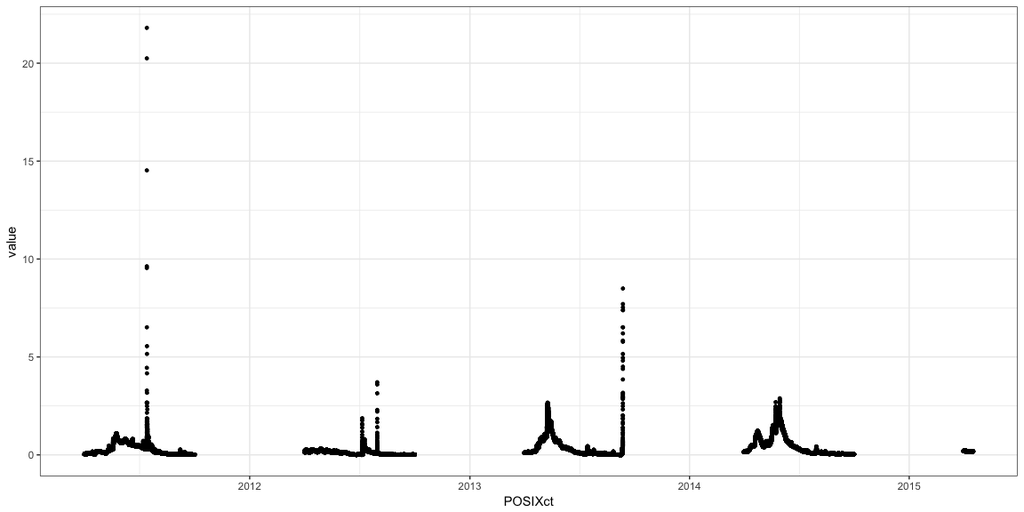

```r
oroPlot <- PlotPrettyUsgs(prettyOrodell)
```

# Import modelled and observed datasets

Set a data path to the Fourmile Creek test case.

```r
dataPath <- '~/wrfHydroTestCases/Fourmile_Creek_testcase_v2.0/'
```

```r
modStrd.chrt.fc <- ReadFrxstPts(paste0(dataPath, '/run.ChannelRouting/frxst_pts_out.txt'))
```

```r
modStrd.allrt.fc <- ReadFrxstPts(paste0(dataPath, '/run.FullRouting/frxst_pts_out.txt'))
```

USGS gage observed data at 5-minute intervals. Find the nearest gage to the forecast point in the above files. (The following approach can be used when multiple forecast points are output by the model. The ddply function essentially performs a loop over unique st_id passing the corresponding subset of the data frame modStrd.chrt.fc to the function which just returns the first row’s lon and lat.)

```r
library(plyr)
fcLocation <- ddply(modStrd.chrt.fc, .(st_id), function(df) df[1,c('st_lon','st_lat')])
near <- FindUsgsStns(stnLon=c(fcLocation$st_lon), stnLat=c(fcLocation$st_lat), within=.005)
near
```

| stnLon | stnLat | within | siteType | hasDataTypeCd | agency_cd | site_no | station_nm | site_tp_cd | dec_lat_va | dec_long_va | colocated | queryTime |
| --- | --- | --- | --- | --- | --- | --- | --- | --- | --- | --- | --- | --- |
| -105.3278 | 40.01932 | 0.005 | ST | iv | USGS | 06727500 | FOURMILE CREEK AT ORODELL, CO | ST | 40.01867 | -105.3263 | FALSE | 2017-05-01 16:43:19 |

The following checks to see if the data are local and gets them if not. The ‘00060’ product (streamflow) is returned and then made pretty, including conversion to metric.

```r
dbPath <- '~/wrfHydroTestCases/usgsDb/'
obsStr5min.fc <-
  PrettyUsgs(QueryHaveSite(near$site_no, path=dbPath, ret='00060', get=TRUE))
obsStr5min.fc <- plyr::rename(obsStr5min.fc, c(value='q_cms'))
```

# Plot hydrographs

Compare hydrographs for the full model run.

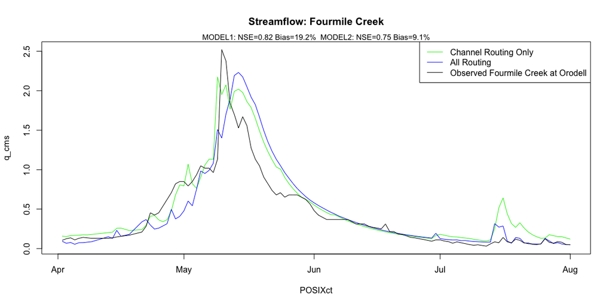

```r
PlotFluxCompare(obsStr5min.fc, "q_cms", modStrd.chrt.fc, "q_cms", strDf.mod2=modStrd.allrt.fc,
     strCol.mod2="q_cms", labelObs="Observed Fourmile Creek at Orodell",
     labelMod1="Channel Routing Only", labelMod2="All Routing",
     title="Streamflow: Fourmile Creek")
```

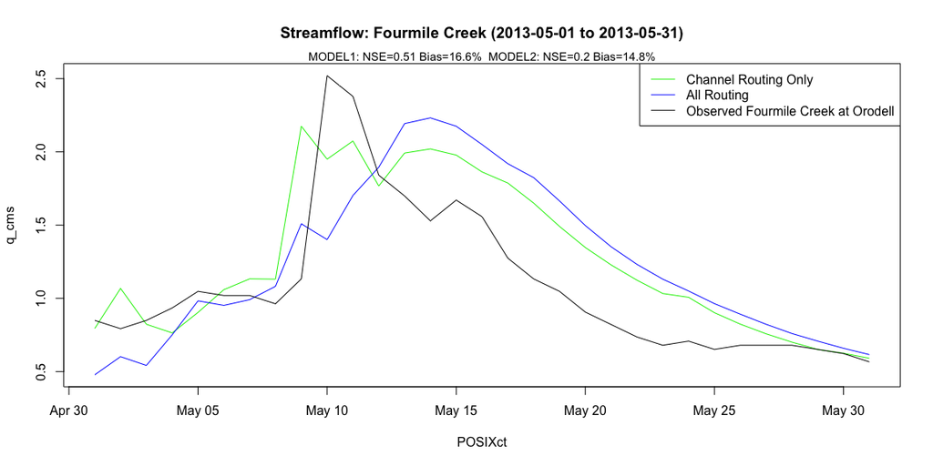

```r
PlotFluxCompare(obsStr5min.fc, "q_cms", modStrd.chrt.fc, "q_cms", strDf.mod2=modStrd.allrt.fc,
     strCol.mod2="q_cms", labelObs="Observed Fourmile Creek at Orodell",
     labelMod1="Channel Routing Only", labelMod2="All Routing",
     title="Streamflow: Fourmile Creek",
     stdate=as.POSIXct("2013-05-01 00:00:00", format="%Y-%m-%d %H:%M:%S", tz="UTC"),
     enddate=as.POSIXct("2013-05-31 00:00:00", format="%Y-%m-%d %H:%M:%S", tz="UTC"))
```

# Review flow duration curves

**NOTE**: You generally evaluate flow duration curves and staistics over much longer time periods (e.g., multiple years) than what we demo here. To make the test case more portable, we are only evaluating once-a-day model output over 5 months.

Calculate percent exceedances for flow duration curves. Note that we need to subset the observations to match our model run output times, and vice versa.

```r
obsStr5min.comp.fc <- CalcFdc(subset(obsStr5min.fc, POSIXct %in% c(modStrd.chrt.fc$POSIXct)))
modStrd.chrt.comp.fc <- CalcFdc(subset(modStrd.chrt.fc, POSIXct %in% c(obsStr5min.comp.fc$POSIXct)))
modStrd.allrt.comp.fc <- CalcFdc(subset(modStrd.allrt.fc, POSIXct %in% c(obsStr5min.comp.fc$POSIXct)))
```

Compare how the models are doing predicting flow values that will be exceeded 20% of the time. First, calculate the fitted spline functions.

```r
fdc.obsStr5min.comp.fc <- CalcFdcSpline(obsStr5min.comp.fc)
fdc.modStrd.chrt.comp.fc <- CalcFdcSpline(modStrd.chrt.comp.fc)
fdc.modStrd.allrt.comp.fc <- CalcFdcSpline(modStrd.allrt.comp.fc)
```

Then, evaluate at the 20% exceedance percentage (high flows).

```r
fdc.obsStr5min.comp.fc(0.2)
fdc.modStrd.chrt.comp.fc(0.2)
fdc.modStrd.allrt.comp.fc(0.2)
```

```
## [1] 0.7706495
## [1] 0.8170807
## [1] 0.7931814
```

Now try the 80% exceedance percentage (low flows).

```r
fdc.obsStr5min.comp.fc(0.8)
fdc.modStrd.chrt.comp.fc(0.8)
fdc.modStrd.allrt.comp.fc(0.8)
```

```
## [1] 0.08530777
## [1] 0.1557625
## [1] 0.09120762
```

Plot flow duration curves for a more complete picture. This tool will do the date matching for us, so no need to subset the datasets.

```
## [1] "Combined min flow for y-axis (capped at 0.001): 0.03114853126"
## [1] "Combined max flow for y-axis: 2.5201993474"
```

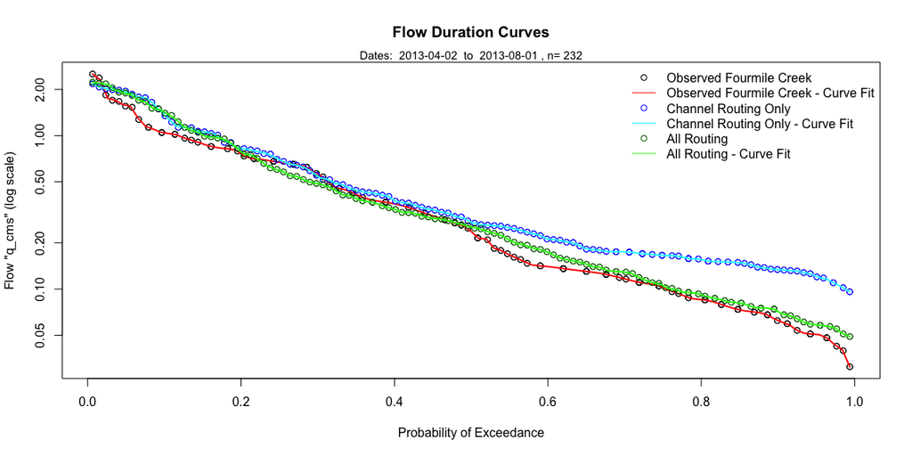

```r
PlotFdcCompare(obsStr5min.fc, "q_cms", modStrd.chrt.fc, "q_cms", strDf.mod2=modStrd.allrt.fc,
     strCol.mod2="q_cms", labelObs="Observed Fourmile Creek",
     labelMod1="Channel Routing Only", labelMod2="All Routing")
```

# Review model performance statistics

Calculate model performance stats (special formatting comands hidden). Again, this tool does the date matching for us.

```r
CalcModPerf(modStrd.chrt.fc, obsStr5min.fc)
```

|  | n | nse | nselog | cor | rmse | rmsenorm | bias | msd | mae | errcom | errmaxt | errfdc |
| --- | --- | --- | --- | --- | --- | --- | --- | --- | --- | --- | --- | --- |
| **units** | count | unitless | unitless | unitless | flux units | unitless | percent | flux units | flux units | hours\|days | hours\|days | flux units |
| **t** | 232 | 0.82 | 0.73 | 0.93 | 0.2067 | 8.31 | 19.2 | 0.0846 | 0.1305 | NA | NA | 0.08 |
| **daily** | 116 | 0.82 | 0.73 | 0.93 | 0.2067 | 8.31 | 19.2 | 0.0846 | 0.1305 | 0 | 0 | 0.08 |
| **monthly** | 5 | 0.92 | 0.7 | 0.99 | 0.1044 | 10.07 | 21.5 | 0.0768 | 0.0806 | -0.2 | -0.2 | NA |
| **yearly** | 1 | NA | NA | NA | NA | NA | 19.2 | 0.0846 | 0.0846 | 3 | -1 | NA |
| **max10** | 24 | -0.04 | -0.08 | 0.5 | 0.4806 | 32.64 | 15 | 0.235 | 0.417 | NA | NA | NA |
| **min10** | 24 | -82.69 | -24.6 | 0.53 | 0.078 | 250.56 | 152.6 | 0.076 | 0.076 | NA | NA | NA |

```r
CalcModPerf(modStrd.allrt.fc, obsStr5min.fc)
```

|  | n | nse | nselog | cor | rmse | rmsenorm | bias | msd | mae | errcom | errmaxt | errfdc |
| --- | --- | --- | --- | --- | --- | --- | --- | --- | --- | --- | --- | --- |
| **units** | count | unitless | unitless | unitless | flux units | unitless | percent | flux units | flux units | hours\|days | hours\|days | flux units |
| **t** | 116 | 0.75 | 0.87 | 0.9 | 0.2462 | 9.89 | 9.1 | 0.0399 | 0.1402 | NA | NA | 0.03 |
| **daily** | 116 | 0.75 | 0.87 | 0.9 | 0.2462 | 9.89 | 9.1 | 0.0399 | 0.1402 | 0 | 0 | 0.03 |
| **monthly** | 5 | 0.95 | 0.95 | 0.99 | 0.0867 | 8.36 | 7 | 0.0251 | 0.0645 | -0.6 | 0 | NA |
| **yearly** | 1 | NA | NA | NA | NA | NA | 9.1 | 0.0399 | 0.0399 | 3 | 4 | NA |
| **max10** | 12 | -0.63 | -0.51 | 0.11 | 0.6034 | 40.98 | 14.4 | 0.2264 | 0.5365 | NA | NA | NA |
| **min10** | 12 | -13.12 | -6.56 | -0.08 | 0.0321 | 102.9 | 49.8 | 0.0248 | 0.0252 | NA | NA | NA |

Help on CalcModPerf gives details on the individual statistics returned.

```r
help(CalcModPerf)
```

```
## Using development documentation for CalcModPerf
```

```
## Using development documentation for CalcModPerf
```

Calculate flow duration curve performance statistics.

```r
CalcFdcPerf(modStrd.allrt.fc, obsStr5min.fc)
```

| p.exceed | q.mod | q.obs | q.err | q.perr |
| --- | --- | --- | --- | --- |
| 0.1 | 1.43 | 1.04 | 0.39 | 37.5 |
| 0.2 | 0.79 | 0.77 | 0.02 | 2.6 |
| 0.3 | 0.49 | 0.56 | -0.07 | -12.5 |
| 0.4 | 0.33 | 0.36 | -0.03 | -8.3 |
| 0.5 | 0.25 | 0.24 | 0.01 | 4.2 |
| 0.6 | 0.17 | 0.14 | 0.03 | 21.4 |
| 0.7 | 0.13 | 0.12 | 0.01 | 8.3 |
| 0.8 | 0.09 | 0.09 | 0 | 0 |
| 0.9 | 0.07 | 0.06 | 0.01 | 16.7 |

Again, help on CalcFdcPerf gives details on the individual statistics returned.

```r
help(CalcFdcPerf)
```

```
## Using development documentation for CalcFdcPerf
```

```
## Using development documentation for CalcFdcPerf
```

# GagesII Attributes

We’ve imported the gages-II atributes to be directly available in R.

```r
head(gages2Attr)
```

| STAID | STANAME | CLASS | AGGECOREGI | DRAIN_SQKM | HUC02 | LAT_GAGE | LNG_GAGE | STATE | HCDN_2009 | ACTIVE09 | FLYRS1900 | FLYRS1950 | FLYRS1990 |
| --- | --- | --- | --- | --- | --- | --- | --- | --- | --- | --- | --- | --- | --- |
| 01011000 | Allagash River near Allagash, Maine | Non-ref | NorthEast | 3186.8440 | 01 | 47.06961 | -69.07954 | ME |  | yes | 78 | 60 | 20 |
| 01013500 | Fish River near Fort Kent, Maine | Ref | NorthEast | 2252.6960 | 01 | 47.23739 | -68.58264 | ME | yes | yes | 85 | 60 | 20 |
| 01015800 | Aroostook River near Masardis, Maine | Non-ref | NorthEast | 2313.7550 | 01 | 46.52300 | -68.37176 | ME |  | yes | 51 | 51 | 19 |
| 01016500 | MACHIAS RIVER NEAR ASHLAND, ME | Non-ref | NorthEast | 847.7721 | 01 | 46.62831 | -68.43479 | ME |  |  | 32 | 32 | 0 |
| 01017000 | Aroostook River at Washburn, Maine | Non-ref | NorthEast | 4278.9070 | 01 | 46.77729 | -68.15719 | ME |  | yes | 79 | 60 | 20 |
| 01017060 | Hardwood Brook below Glidden Brk nr Caribou, Maine | Non-ref | NorthEast | 14.8644 | 01 | 46.78361 | -67.98917 | ME |  | yes | 0 | 0 | 0 |

```r
?gages2Attr
```

```
## Using development documentation for gages2Attr
```